# Exploratory Analysis

# MISSING MIGRANTS

The initial dataset contains 4286 data items and the following data attributes.

- **region** The region in which the incident took place
- **date** Estimated date of death
- **year** The year in which the incident occurred
- **deaths** The sum of the number of dead and missing
- **women** The number of females found dead or missing. If unknown, it is left blank.
- **men** The number of males found dead or missing. If unknown, it is left blank.
- **children** The number of individuals under the age of 18 found dead or missing. If unknown, it is left blank.
- **survivors** The number of migrants that survived the incident, if known
- **cause_of_death** The determination of conditions resulting in the migrant’s death
- **location_description** Place where the death(s) occurred or where the body or bodies were found
- **location_coordinates** Place where the death(s) occurred or where the body or bodies were found
- **url** Articles that reported the incident

One of the dimensions I intend to investigate is the **information richness**. So I need a dataset with as much complete data as possible. The first decision is considering only the rows that contain the number of dead women and children.

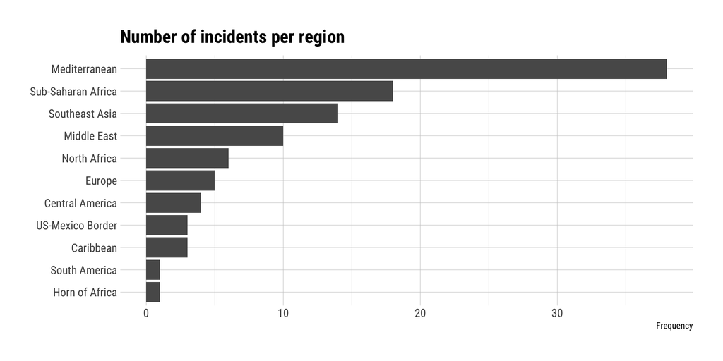

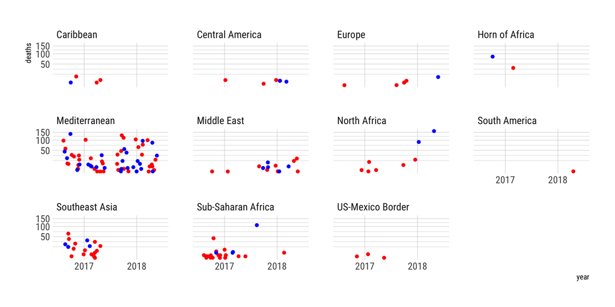

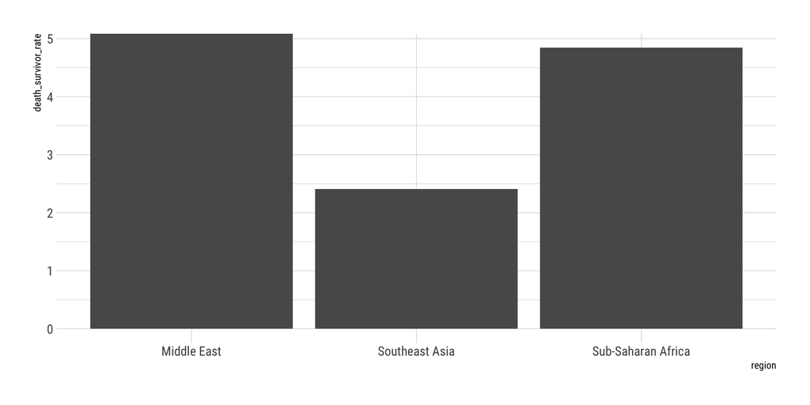

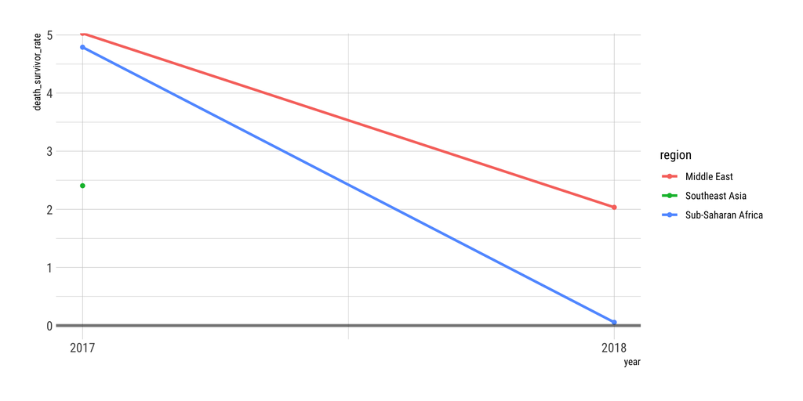

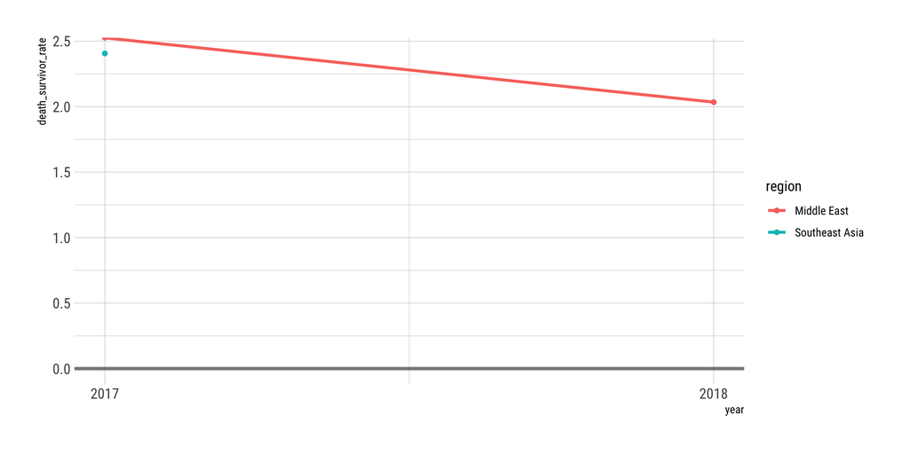

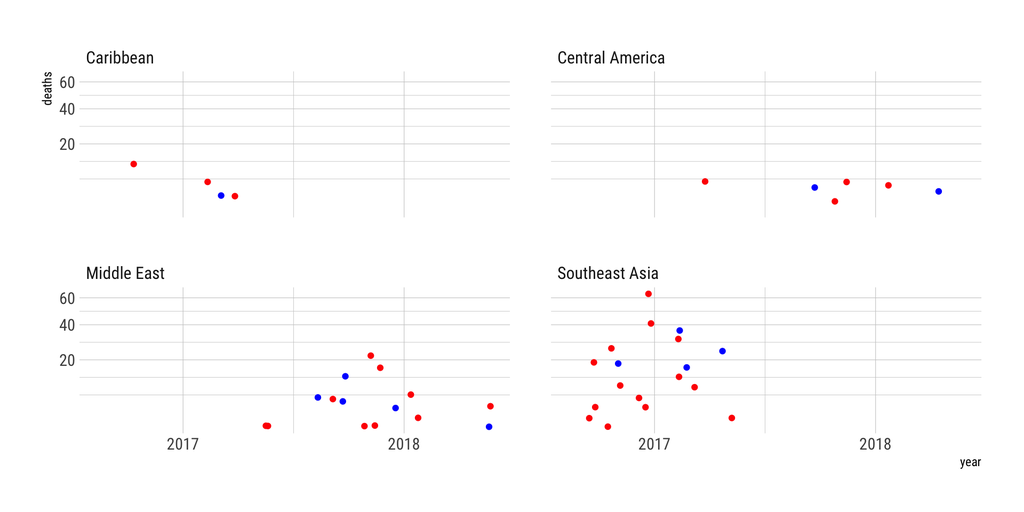

# DEATHS AT THE BORDERS

## Identification of incidents

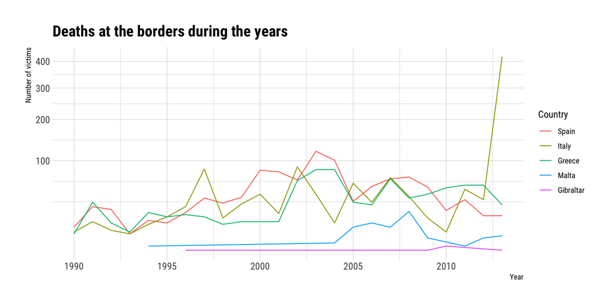

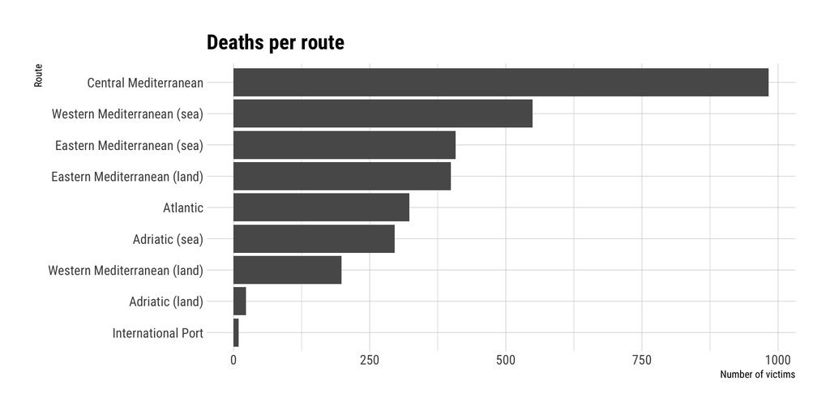

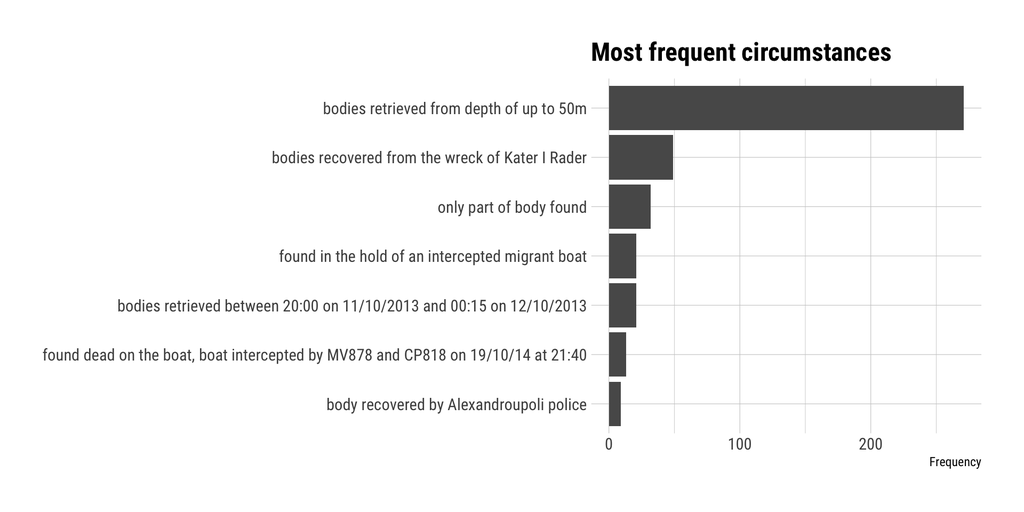

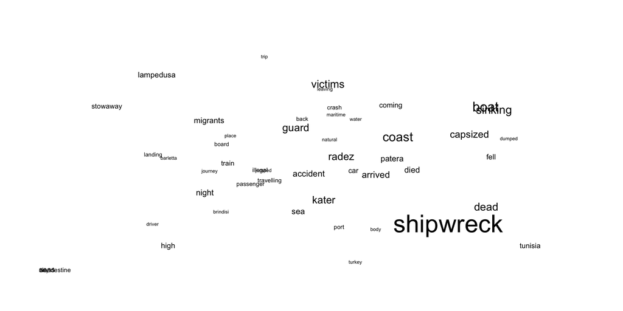

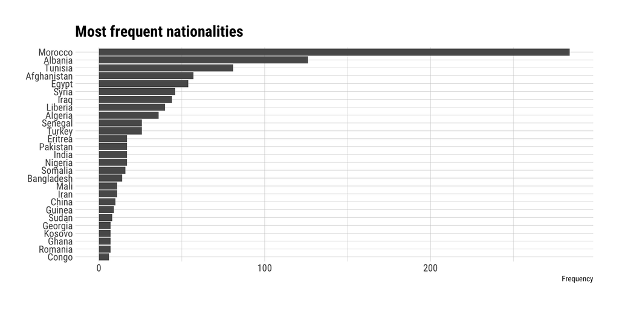

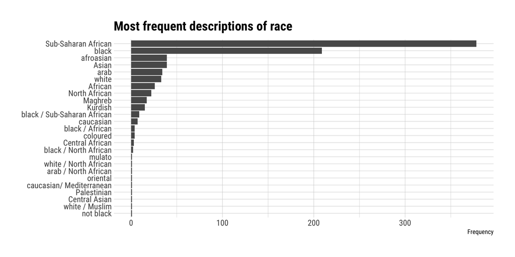

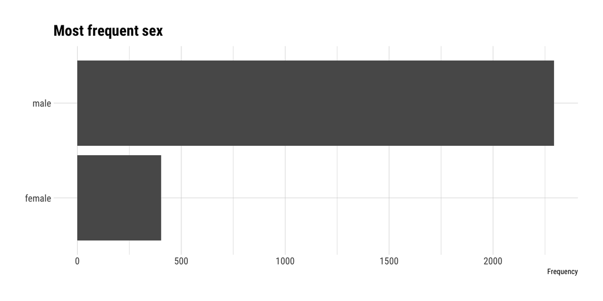

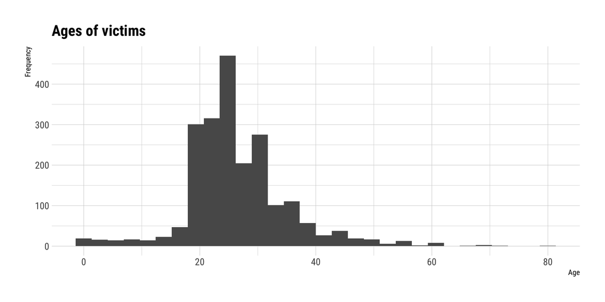